# featureSelection_training_crossValidation

### Feature Selection Methods

#### 1) Recursive Feature Elimination with Cross-Validation (RFECV)

- **Recursive Feature Elimination** fits a model that starts with all the input variables, then iteratively removes those with the weakest relationship with the output until the desired number of features is reached. It actually fits a model instead of just running statistical tests unlike the Univariate Testing.
- **RFE** is popular because it is easy to configure and use and because it is effective at selecting those features in a training dataset that are more or most relevant in predicting the target variable.”
- **The CV in RFECV means Cross-Validation** gives you a better understanding on what the variables will be included in your model. In the Cross-Validation part, it splits the data into different chunks and iteratively trains and validates models on each chunks separately. This simply means that each time you assess different models with certain variables included or eliminated, the algorithm also knows how accurate each model was from the model scenarios that are created and can determine which provided the best accuracy and concludes the best set of input variables to use.

#### Magnitude and significance of Model cofficients

For logistic regression, feature importance is primarily determined by the magnitude and statistical significance of the coefficients assigned to each feature in the model. Features with larger coefficients and lower p-values are typically considered more important for predicting the outcome variable.

```python
### IMPORT IMPORTANT LIBERARIES

### Data Handling and Manipulation
import pandas as pd
import numpy as np

### Visualization:
import matplotlib.pyplot as plt
import seaborn as sns

### Statistical Modeling
import statsmodels.api as sm

### Feature Selection and Modeling
from sklearn.feature_selection import RFECV, SelectKBest, f_classif
from sklearn.ensemble import RandomForestClassifier
from sklearn.linear_model import LogisticRegression
from sklearn.tree import DecisionTreeClassifier, plot_tree

### Evaluation Metrics and Cross-Validation
from sklearn.metrics import confusion_matrix, accuracy_score, precision_score, recall_score, f1_score
from sklearn.model_selection import StratifiedKFold, train_test_split, cross_val_score, cross_val_predict, GridSearchCV
```

```python
# read the the clean csv file into as a new DataFrame
diabetes_clean = pd.read_csv("C:/Users/yitay/Documents/CIND820/diabetes_prediction/Initial result and Codes/diabetes_clean.csv", sep=',')
```

```python
diabetes_clean.head()
```

|  | diabetes | bp | chol | cholcheck | bmi | smoker | stroke | heart_disease | activity | fruits | ... | healthcare | nodocbccost | genhlth | menthlth | phyhlth | walk | sex | age | education | income |
| --- | --- | --- | --- | --- | --- | --- | --- | --- | --- | --- | --- | --- | --- | --- | --- | --- | --- | --- | --- | --- | --- |
| 0 | 0 | 1 | 0 | 1 | 0.552109 | 0 | 0 | 0 | 1 | 0 | ... | 1 | 0 | 1 | 1 | 2 | 0 | 1 | 1 | 2 | 2 |
| 1 | 0 | 1 | 1 | 1 | 0.552109 | 1 | 1 | 0 | 0 | 1 | ... | 1 | 0 | 1 | 0 | 0 | 0 | 1 | 3 | 2 | 2 |
| 2 | 0 | 0 | 0 | 1 | 0.552109 | 0 | 0 | 0 | 1 | 1 | ... | 1 | 0 | 0 | 0 | 1 | 0 | 1 | 3 | 2 | 2 |
| 3 | 0 | 1 | 1 | 1 | 0.612179 | 1 | 0 | 0 | 1 | 1 | ... | 1 | 0 | 1 | 0 | 0 | 0 | 1 | 3 | 2 | 2 |
| 4 | 0 | 0 | 0 | 1 | 0.640678 | 1 | 0 | 0 | 1 | 1 | ... | 1 | 0 | 1 | 0 | 0 | 0 | 0 | 2 | 2 | 2 |

5 rows × 22 columns

```python
print(diabetes_clean.shape)
```

```
(66876, 22)
```

#### Logistic Regression - Feature Selection using Model coefficients and p-values

- Split the dataset into training and testing sets (80:20 split).
- Perform feature selection using Logistic Regression only on the training set
- Visualize the feature importance based on the absolute values of the coefficients
- select those features whose coefficient's p-value is 0.05 or less

Selected features with cofficients having p value 0.05 or lower

```
Optimization terminated successfully.
         Current function value: 0.530300
         Iterations 6
Selected Features with P-value <= 0.05:
========================================
Feature        Coefficient   P-value
========================================
bmi                  3.44     0.000
cholcheck            1.35     0.000
alcohol             -0.81     0.000
genhlth              0.81     0.000
bp                   0.76     0.000
chol                 0.59     0.000
age                  0.46     0.000
heart_disease        0.35     0.000
walk                 0.30     0.000
sex                  0.27     0.000
income              -0.22     0.000
stroke               0.21     0.000
education           -0.10     0.000
activity            -0.08     0.001
phyhlth              0.07     0.000
veggies             -0.05     0.037
```

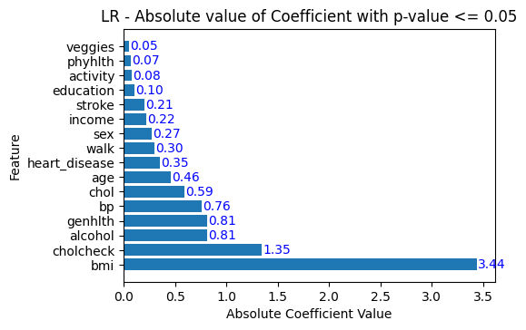

```python
##   Select features with cofficients having p value 0.05 or lower

# Separate Features (X) and Target (y)
X = diabetes_clean.drop("diabetes", axis=1)
y = diabetes_clean["diabetes"]

# Split the dataset into training and testing sets (80:20 split)
X_train, X_test, y_train, y_test = train_test_split(X, y, test_size=0.2, random_state=42)

# Add a constant to the training data for statsmodels
X_train_sm = sm.add_constant(X_train)

# Use statsmodels to fit logistic regression and calculate p-values
logit_model = sm.Logit(y_train, X_train_sm)
result = logit_model.fit()

# Get the p-values and coefficients
p_values = result.pvalues[1:]  # Exclude the constant term
log_reg_coefficients = result.params[1:]  # Exclude the constant term

# Filter features based on p-value threshold of 0.05
selected_indices = [i for i, p in enumerate(p_values) if p <= 0.05]

# Get the selected features, coefficients, and p-values
selected_features = X_train.columns[selected_indices]
selected_coefficients = log_reg_coefficients[selected_indices]
selected_p_values = p_values[selected_indices]

# Create a DataFrame to hold selected coefficients and p-values
coef_pval_df = pd.DataFrame({
    'Feature': selected_features,
    'Coefficient': selected_coefficients,
    'P-value': selected_p_values
}).sort_values(by='Coefficient', key=abs, ascending=False)

# Print selected features, their coefficients, and p-values
print("Selected Features with P-value <= 0.05:")
print("=" * 40)
print(f"{'Feature':<15}{'Coefficient':>10}{'P-value':>10}")
print("=" * 40)
for _, row in coef_pval_df.iterrows():
    print(f"{row['Feature']:<15}{row['Coefficient']:>10.2f}{row['P-value']:>10.3f}")

# Create a single subplot to visualize feature importance
fig, ax = plt.subplots(figsize=(6,4))

# Plot Logistic Regression Coefficient Magnitude (in decreasing order)
abs_coefficients = abs(coef_pval_df['Coefficient'])
sorted_indices = abs_coefficients.argsort()[::-1]
ax.barh(range(len(sorted_indices)), abs_coefficients[sorted_indices])
ax.set_yticks(range(len(sorted_indices)))
ax.set_yticklabels(coef_pval_df['Feature'].values[sorted_indices], fontsize=10)
ax.set_xlabel('Absolute Coefficient Value')
ax.set_ylabel('Feature')
ax.set_title('LR - Absolute value of Coefficient with p-value <= 0.05')

# Annotate the values on the bars
for i, v in enumerate(abs_coefficients[sorted_indices]):
    ax.text(v + 0.01, i, f'{v:.2f}', color='blue', va='center')

# Adjust layout and display the plot
plt.tight_layout(pad=2.0)
plt.show()
```

```python
# Create a dataframe for the selceted features and the target varible
diabetes_lg_importnce = diabetes_clean[['diabetes','bmi', 'cholcheck', 'alcohol','genhlth', 'bp','chol', 'age','heart_disease','walk','sex','income','stroke','education','activity', 'phyhlth', 'veggies']]
```

```python
# create a list of categorical feature
cat_lg_importance =['age','income','education','genhlth','phyhlth']
```

##### Logistic Regression - Recursive Feature Elimination with Cross validation(RFECV)

To use the training dataset after the train-test split for feature selection using RFECV, the following steps were performed:

- Split the dataset into training and testing sets (80:20 split).
- Perform Recursive Feature Elimination with Cross-Validation (RFECV) on the training set.
- Visualize the feature selection process and display the selected features.

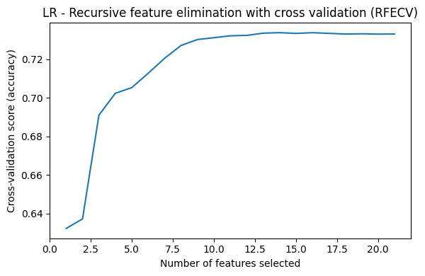

```
Optimal number of features: 14
Selected features: ['bp', 'chol', 'cholcheck', 'bmi', 'stroke', 'heart_disease', 'activity', 'alcohol', 'genhlth', 'walk', 'sex', 'age', 'education', 'income']
Feature ranking: [1 1 1 1 7 1 1 1 6 3 1 8 4 1 5 2 1 1 1 1 1]
```

```python
## Logistic Regression - Recursive Feature Elimination with Cross validation(RFECV)

# Separate features and target variable
X = diabetes_clean.drop("diabetes", axis=1)
y = diabetes_clean["diabetes"]

# Split the dataset into training and testing sets (80:20 split)
X_train, X_test, y_train, y_test = train_test_split(X, y, test_size=0.2, random_state=42)

# Use Logistic Regression for RFE
logreg = LogisticRegression(random_state=42, solver='liblinear')
cv_strategy = StratifiedKFold(n_splits=5, shuffle=True, random_state=42)

# Perform Recursive Feature Elimination with Cross-Validation (RFECV) on the training set
rfecv = RFECV(estimator=logreg, step=1, cv=cv_strategy, scoring='accuracy')
rfecv.fit(X_train, y_train)

# Get the feature rankings
ranking = rfecv.ranking_
selected_features = [f for i, f in enumerate(X_train.columns) if ranking[i] == 1]

# Create a single subplot
fig, ax = plt.subplots(figsize=(6,4))

# Plot the number of features vs. cross-validation scores
mean_scores = rfecv.cv_results_['mean_test_score']
ax.plot(range(1, len(mean_scores) + 1), mean_scores)
ax.set_xlabel("Number of features selected")
ax.set_ylabel("Cross-validation score (accuracy)")
ax.set_title("LR - Recursive feature elimination with cross validation (RFECV)")

# Adjust layout and display the plot
plt.tight_layout()
plt.show()

# Display the selected features and their rankings
print("Optimal number of features:", rfecv.n_features_)
print("Selected features:", selected_features)
print("Feature ranking:", ranking)
```

```python
# Create a datafreme for the selected features and the terget variable
diabetes_lg_rfe = [['diabetes','bp', 'chol','cholcheck','bmi','stroke','heart_disease','activity','alcohol','genhlth','walk', 'sex','age','education', 'income']]
```

```python
cat_lg_rfe =['genhlth','age','education','income']
```

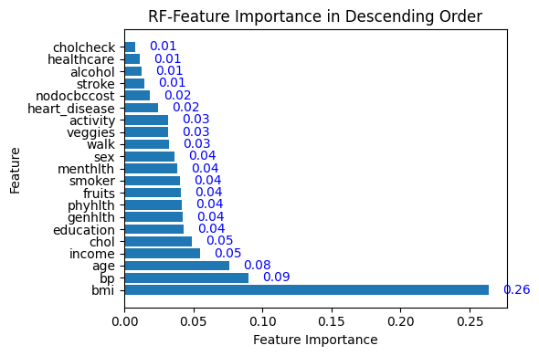

```
Selected features and their importances:
Feature         Importance (%)Cumulative Contribution (%)
============================================================
bmi            0.2636   26.36%   26.36%
bp             0.0902   9.02%   35.38%
age            0.0759   7.59%   42.98%
income         0.0546   5.46%   48.43%
chol           0.0489   4.89%   53.32%
education      0.0427   4.27%   57.59%
genhlth        0.0424   4.24%   61.83%
phyhlth        0.0414   4.14%   65.97%
fruits         0.0413   4.13%   70.10%
smoker         0.0402   4.02%   74.12%
menthlth       0.0380   3.80%   77.92%
sex            0.0362   3.62%   81.54%
walk           0.0321   3.21%   84.75%
veggies        0.0317   3.17%   87.92%
activity       0.0316   3.16%   91.08%
heart_disease  0.0241   2.41%   93.49%
nodocbccost    0.0188   1.88%   95.37%
```

```python
## Decision Tree - Feature Selection using Gini importance (mean decrease in impurity).
# Separate Features (X) and Target (y)
X = diabetes_clean.drop("diabetes", axis=1)
y = diabetes_clean["diabetes"]

# Split the dataset into training and testing sets (80:20 split)
X_train, X_test, y_train, y_test = train_test_split(X, y, test_size=0.2, random_state=42)

# Use Random Forest Classifier for feature selection on the training set
rf_classifier = RandomForestClassifier(n_estimators=100, random_state=42)
rf_classifier.fit(X_train, y_train)
rf_feature_importances = rf_classifier.feature_importances_

# Sort features based on their importance for Random Forest
sorted_rf_indices = np.argsort(rf_feature_importances)[::-1]
sorted_rf_importances = rf_feature_importances[sorted_rf_indices]

# Calculate cumulative contribution
cumulative_contributions = np.cumsum(sorted_rf_importances)

# Find the threshold index where cumulative contribution exceeds 95%
threshold_index = np.argmax(cumulative_contributions >= 0.95)

# Create a single subplot
fig, ax = plt.subplots(figsize=(6,4))

# Plot Random Forest Feature Importance (in decreasing order)
ax.barh(range(len(sorted_rf_indices)), sorted_rf_importances)
ax.set_yticks(range(len(sorted_rf_indices)))
ax.set_yticklabels(X_train.columns[sorted_rf_indices])
ax.set_xlabel('Feature Importance')
ax.set_ylabel('Feature')
ax.set_title('RF-Feature Importance in Descending Order')

# Annotate the values on the bars with importance values
for i, v in enumerate(sorted_rf_importances):
    ax.text(v + 0.01, i, f'{v:.2f}', color='blue', va='center')

# Display the plot
plt.tight_layout()
plt.show()

# Display the selected features and their importances in a nicely aligned format
print("\nSelected features and their importances:")
print(f"{'Feature':<15}{'Importance (%)':>15}{'Cumulative Contribution (%)':>15}")
print("="*60)
for i in range(threshold_index + 1):  # Display features up to the threshold index
    print(f"{X_train.columns[sorted_rf_indices[i]]:<15}{sorted_rf_importances[i]:.4f}   {sorted_rf_importances[i]*100:.2f}%   {cumulative_contributions[i]*100:.2f}%")
```

```python
# Create a dataframe  for the selected features and the target variable
diabetes_dt_importnce = [['diabetes', 'bmi', 'bp','age','income','chol','education','genhlth','phyhlth', 'fruits','smoker','menthlth','sex','walk','veggies','activity','heart_disease','nodocbccost']]
```

```python
cat_dt_importance =['age','income','education','genhlth','phyhlth', 'menthlth']
```

#### Decision Tree - Recursive Feature Elimination with Cross-Validation (RFECV)

To use the training dataset after a train-test split for feature selection using Recursive Feature Elimination with Cross-Validation (RFECV) with a Decision Tree classifier, the following steps used:

- Split the dataset into training and testing sets (80:20 split).
- Perform Recursive Feature Elimination with Cross-Validation (RFECV) on the training set.
- Visualize the feature selection process and display the selected features.

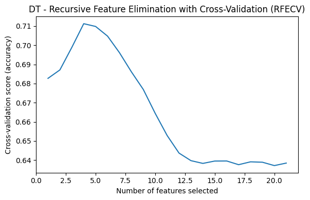

```
Optimal number of features: 4
Selected features: ['bp', 'bmi', 'genhlth', 'age']
Feature ranking: [ 1 11 18  1  5 15 13  7  4  9 17 16 12  1  3  2 14 10  1  6  8]
```

```python
##  Decision Tree - Recursive Feature Elimination with Cross-Validation (RFECV)

# Separate Features (X) and Target (y)
X = diabetes_clean.drop("diabetes", axis=1)
y = diabetes_clean["diabetes"]

# Split the dataset into training and testing sets (80:20 split)
X_train, X_test, y_train, y_test = train_test_split(X, y, test_size=0.2, random_state=42)

# Use Decision Tree Classifier for RFECV
dt_classifier = DecisionTreeClassifier(random_state=42)
cv_strategy = StratifiedKFold(n_splits=5, shuffle=True, random_state=42)

# Perform Recursive Feature Elimination with Cross-Validation (RFECV) on the training set
rfecv = RFECV(estimator=dt_classifier, step=1, cv=cv_strategy, scoring='accuracy')
rfecv.fit(X_train, y_train)

# Get the feature rankings
ranking = rfecv.ranking_
selected_features = [f for i, f in enumerate(X_train.columns) if ranking[i] == 1]

# Create a single subplot
fig, ax = plt.subplots(figsize=(6,4))

# Plot the number of features vs. cross-validation scores
mean_scores = rfecv.cv_results_['mean_test_score']
ax.plot(range(1, len(mean_scores) + 1), mean_scores)
ax.set_xlabel("Number of features selected")
ax.set_ylabel("Cross-validation score (accuracy)")
ax.set_title("DT - Recursive Feature Elimination with Cross-Validation (RFECV)")

# Adjust layout and display the plot
plt.tight_layout()
plt.show()

# Display the selected features and their rankings
print("Optimal number of features:", rfecv.n_features_)
print("Selected features:", selected_features)
print("Feature ranking:", ranking)
```

```python
## createa datafarene for the selceted  features
diabetes_dt_rfe = ['bp', 'bmi','genhlth', 'age']
```

```python
cat_dt_rfe = ['genhlth', 'age']
```

### Random Forest - Feature Selection using gini importance

Feature importance in Random Forests is typically calculated as the average reduction in impurity (e.g., Gini impurity) across all trees in the forest

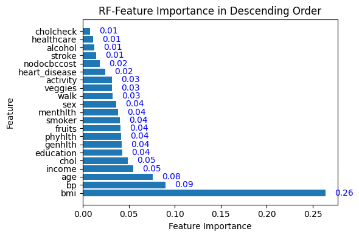

```
Selected features and their importances:
Feature                   Importance (%)   Cumulative Contribution (%)
======================================================================
bmi                 0.2636   26.36%   26.36%
bp                  0.0902   9.02%   35.38%
age                 0.0759   7.59%   42.98%
income              0.0546   5.46%   48.43%
chol                0.0489   4.89%   53.32%
education           0.0427   4.27%   57.59%
genhlth             0.0424   4.24%   61.83%
phyhlth             0.0414   4.14%   65.97%
fruits              0.0413   4.13%   70.10%
smoker              0.0402   4.02%   74.12%
menthlth            0.0380   3.80%   77.92%
sex                 0.0362   3.62%   81.54%
walk                0.0321   3.21%   84.75%
veggies             0.0317   3.17%   87.92%
activity            0.0316   3.16%   91.08%
heart_disease       0.0241   2.41%   93.49%
nodocbccost         0.0188   1.88%   95.37%
```

```python
## Random Forest - Feature Selection using gini importance

# Separate Features (X) and Target (y)
X = diabetes_clean.drop("diabetes", axis=1)
y = diabetes_clean["diabetes"]

# Split the dataset into training and testing sets (80:20 split)
X_train, X_test, y_train, y_test = train_test_split(X, y, test_size=0.2, random_state=42)

# Use Random Forest Classifier for feature selection on the training set
rf_classifier = RandomForestClassifier(n_estimators=100, random_state=42)
rf_classifier.fit(X_train, y_train)
rf_feature_importances = rf_classifier.feature_importances_

# Sort features based on their importance for Random Forest
sorted_rf_indices = np.argsort(rf_feature_importances)[::-1]
sorted_rf_importances = rf_feature_importances[sorted_rf_indices]

# Calculate cumulative contribution
cumulative_contributions = np.cumsum(sorted_rf_importances)

# Find the threshold index where cumulative contribution exceeds 95%
threshold_index = np.argmax(cumulative_contributions >= 0.95)

# Create a single subplot
fig, ax = plt.subplots(figsize=(6, 4))

# Plot Random Forest Feature Importance (in decreasing order)
ax.barh(range(len(sorted_rf_indices)), sorted_rf_importances)
ax.set_yticks(range(len(sorted_rf_indices)))
ax.set_yticklabels(X_train.columns[sorted_rf_indices])
ax.set_xlabel('Feature Importance')
ax.set_ylabel('Feature')
ax.set_title('RF-Feature Importance in Descending Order')

# Annotate the values on the bars with importance values
for i, v in enumerate(sorted_rf_importances):
    ax.text(v + 0.01, i, f'{v:.2f}', color='blue', va='center')

# Display the plot
plt.tight_layout()
plt.show()

# Display the selected features and their importances in a nicely aligned format
print("\nSelected features and their importances:")
print(f"{'Feature':<20}{'Importance (%)':>20}{'Cumulative Contribution (%)':>30}")
print("="*70)
for i in range(threshold_index + 1):  # Display features up to the threshold index
    print(f"{X_train.columns[sorted_rf_indices[i]]:<20}{sorted_rf_importances[i]:.4f}   {sorted_rf_importances[i]*100:.2f}%   {cumulative_contributions[i]*100:.2f}%")
```

```python
# Create a dataframe using the selected features
# features whose cumulative importance = 95% are selected, ie. the last 4 are not selected

diabetes_rf_importnce = [['bmi', 'bp','age','income','chol','education','genhlth','phyhlth', 'fruits','smoker','menthlth','sex','walk','veggies','activity','heart_disease','nodocbccost']]
```

```python
cat_rf_importance =['age','income','education','genhlth','phyhlth', 'menthlth']
```

##### Random Forest - Recursive Feature Elimination with cross validation(RFECV)

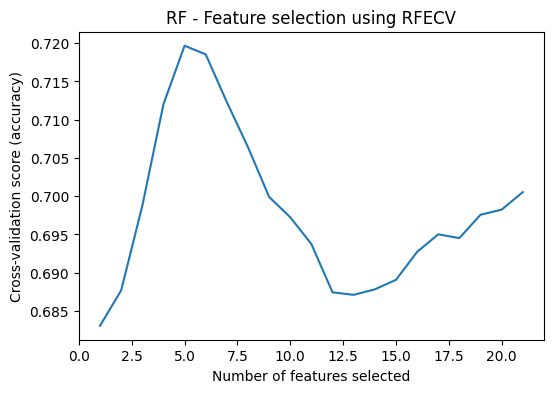

```
Optimal number of features: 5
Selected features: ['bp', 'chol', 'bmi', 'genhlth', 'age']
Feature ranking: [ 1  1 17  1  8 14 12 10  7 11 15 16 13  1  4  5  2  9  1  6  3]
```

```python
## Random Forest - Recursive Feature Elimination with cross validation(RFECV)

# Separate features and target variable
X = diabetes_clean.drop("diabetes", axis=1)
y = diabetes_clean["diabetes"]

# Use Random Forest Classifier for RFE
rf_classifier = RandomForestClassifier(random_state=42)

# Define the cross-validation strategy
cv_strategy = StratifiedKFold(n_splits=5, shuffle=True, random_state=42)

# Perform Recursive Feature Elimination with Cross-Validation (RFECV)
rfecv = RFECV(estimator=rf_classifier, step=1, cv=cv_strategy, scoring='accuracy')
rfecv.fit(X, y)

# Get the feature rankings
ranking = rfecv.ranking_
selected_features = [f for i, f in enumerate(X.columns) if ranking[i] == 1]

# Create a single subplot
fig, ax = plt.subplots(figsize=(6,4))

# Plot the number of features vs. cross-validation scores
mean_scores = rfecv.cv_results_['mean_test_score']
ax.plot(range(1, len(mean_scores) + 1), mean_scores)
ax.set_xlabel("Number of features selected")
ax.set_ylabel("Cross-validation score (accuracy)")
ax.set_title("RF - Feature selection using RFECV")

# Adjust layout and display the plot
plt.show()

# Display the selected features and their rankings
print("Optimal number of features:", rfecv.n_features_)
print("Selected features:", selected_features)
print("Feature ranking:", ranking)
```

```python
diabetes_rf_rfe = [['bp', 'chol', 'bmi','genhlth', 'age']]
```

```python
cat_rf_rfe = ['genhlth', 'age']
```

### Model Training, 5-Fold Cross Validation and Testing

# ------------------------------------------------------------

#### 1) Base Model

The baseline model includes all 21 features and is based on one-hot encoding of categorical features. This approach provides a consistent and neutral representation of categorical variables that can be effectively used across these 3 different types of algorithms. Despite leading to high dimensionality data, using one-Hot encoding of categorical features avoids introduction of ordinal relationships in categories and is widely used and generally safe approach.

# ------------------------------------------------------------

```python
diabetes_clean.head()
```

|  | diabetes | bp | chol | cholcheck | bmi | smoker | stroke | heart_disease | activity | fruits | ... | healthcare | nodocbccost | genhlth | menthlth | phyhlth | walk | sex | age | education | income |
| --- | --- | --- | --- | --- | --- | --- | --- | --- | --- | --- | --- | --- | --- | --- | --- | --- | --- | --- | --- | --- | --- |
| 0 | 0 | 1 | 0 | 1 | 0.552109 | 0 | 0 | 0 | 1 | 0 | ... | 1 | 0 | 1 | 1 | 2 | 0 | 1 | 1 | 2 | 2 |
| 1 | 0 | 1 | 1 | 1 | 0.552109 | 1 | 1 | 0 | 0 | 1 | ... | 1 | 0 | 1 | 0 | 0 | 0 | 1 | 3 | 2 | 2 |
| 2 | 0 | 0 | 0 | 1 | 0.552109 | 0 | 0 | 0 | 1 | 1 | ... | 1 | 0 | 0 | 0 | 1 | 0 | 1 | 3 | 2 | 2 |
| 3 | 0 | 1 | 1 | 1 | 0.612179 | 1 | 0 | 0 | 1 | 1 | ... | 1 | 0 | 1 | 0 | 0 | 0 | 1 | 3 | 2 | 2 |
| 4 | 0 | 0 | 0 | 1 | 0.640678 | 1 | 0 | 0 | 1 | 1 | ... | 1 | 0 | 1 | 0 | 0 | 0 | 0 | 2 | 2 | 2 |

5 rows × 22 columns

### One-Hot encoding of categorical features in "diabetes_clean" dataframe

```python
# Create a list categorical features for the diabetes dataset
cat_features = ['genhlth', 'menthlth', 'phyhlth', 'age', 'education', 'income']
```

```python
# Create a copy of the 'diabetes' dataframe in memory with a different name, 'diabetes_onehot'
diabetes_onehot=diabetes_clean.copy()
# convert only categorical variables/features to dummy/one-hot features
diabetes_onehot = pd.get_dummies(diabetes_clean, columns=cat_features, prefix = cat_features)
# Replace True/False with 1/0
diabetes_onehot = diabetes_onehot.replace({True: 1, False: 0})
#print the dataset
diabetes_onehot.head()
```

|  | diabetes | bp | chol | cholcheck | bmi | smoker | stroke | heart_disease | activity | fruits | ... | age_0 | age_1 | age_2 | age_3 | education_0 | education_1 | education_2 | income_0 | income_1 | income_2 |
| --- | --- | --- | --- | --- | --- | --- | --- | --- | --- | --- | --- | --- | --- | --- | --- | --- | --- | --- | --- | --- | --- |
| 0 | 0 | 1 | 0 | 1 | 0.552109 | 0 | 0 | 0 | 1 | 0 | ... | 0 | 1 | 0 | 0 | 0 | 0 | 1 | 0 | 0 | 1 |
| 1 | 0 | 1 | 1 | 1 | 0.552109 | 1 | 1 | 0 | 0 | 1 | ... | 0 | 0 | 0 | 1 | 0 | 0 | 1 | 0 | 0 | 1 |
| 2 | 0 | 0 | 0 | 1 | 0.552109 | 0 | 0 | 0 | 1 | 1 | ... | 0 | 0 | 0 | 1 | 0 | 0 | 1 | 0 | 0 | 1 |
| 3 | 0 | 1 | 1 | 1 | 0.612179 | 1 | 0 | 0 | 1 | 1 | ... | 0 | 0 | 0 | 1 | 0 | 0 | 1 | 0 | 0 | 1 |
| 4 | 0 | 0 | 0 | 1 | 0.640678 | 1 | 0 | 0 | 1 | 1 | ... | 0 | 0 | 1 | 0 | 0 | 0 | 1 | 0 | 0 | 1 |

5 rows × 35 columns

### 1.1) Logistic Regression Base Model

- All 21 features used
- one-Hot encoded categorical features
- Simple 80:20 train-test split
- default hyperparameters

```
- Test Confusion Matrix:
[[4759 1918]
 [1554 5145]]
```

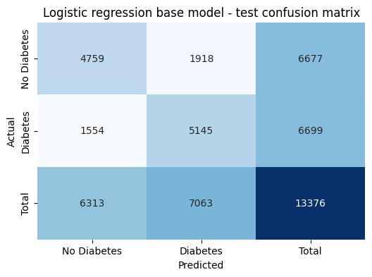

```
- Test Accuracy: 0.7404306220095693
- Test Precision: 0.7284440039643211
- Test Recall: 0.768025078369906
- Test F1 Score: 0.7477110885045779
```

```python
## 1.1) Logistic Regression Base Model

# Separate features and target variable
X = diabetes_onehot.drop("diabetes", axis=1)
y = diabetes_onehot["diabetes"]

# Split the dataset into training and testing sets (80:20 split)
X_train, X_test, y_train, y_test = train_test_split(X, y, test_size=0.2, random_state=42)

# Initialize the Logistic Regression model with increased iterations
logreg = LogisticRegression(
    random_state=42,
    max_iter=1000,  # Increase max_iter as needed
    C=1,            # Default regularization strength
    penalty='l2',   # Default regularization penalty
    solver='lbfgs'  # Default solver
)

# Fit the model on the entire training set
logreg.fit(X_train, y_train)

# Test the model performance on the test set
y_test_pred = logreg.predict(X_test)

# Compute and print the confusion matrix for the test set
conf_matrix_test = confusion_matrix(y_test, y_test_pred)
print("- Test Confusion Matrix:")
print(conf_matrix_test)

# Function to plot confusion matrix with totals
def plot_confusion_matrix_with_totals(conf_matrix, title):
    cm_with_totals = conf_matrix.copy()
    cm_with_totals = np.vstack([cm_with_totals, np.sum(cm_with_totals, axis=0)])
    cm_with_totals = np.hstack([cm_with_totals, np.sum(cm_with_totals, axis=1).reshape(-1, 1)])

    cm_df = pd.DataFrame(cm_with_totals, index=['No Diabetes', 'Diabetes', 'Total'], columns=['No Diabetes', 'Diabetes', 'Total'])

    plt.figure(figsize=(6, 4))
    sns.heatmap(cm_df, annot=True, fmt='d', cmap='Blues', cbar=False)
    plt.title(title)
    plt.xlabel('Predicted')
    plt.ylabel('Actual')
    plt.show()

# Plot the confusion matrix for the test set
plot_confusion_matrix_with_totals(conf_matrix_test, 'Logistic regression base model - test confusion matrix')

# Compute and print additional evaluation metrics for the test set
accuracy_test = accuracy_score(y_test, y_test_pred)
precision_test = precision_score(y_test, y_test_pred)
recall_test = recall_score(y_test, y_test_pred)
f1_test = f1_score(y_test, y_test_pred)

print("- Test Accuracy:", accuracy_test)
print("- Test Precision:", precision_test)
print("- Test Recall:", recall_test)
print("- Test F1 Score:", f1_test)
```

### 1.2) Decision Tree Base Model

- All 21 features used
- one-Hot encoded categorical features
- Simple 80:20 train-test split
- default hyperparameters

```
- Test Confusion Matrix:
[[4481 2196]
 [2661 4038]]
```

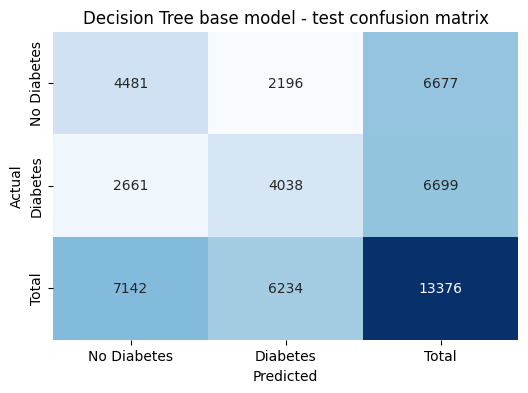

```
- Test Accuracy: 0.636886961722488
- Test Precision: 0.6477382098171318
- Test Recall: 0.6027765338110166
- Test F1 Score: 0.6244490837392717
```

```python
##  1.2) Decision Tree Base Model

# Separate features and target variable
X = diabetes_onehot.drop("diabetes", axis=1)
y = diabetes_onehot["diabetes"]

# Split the dataset into training and testing sets (80:20 split)
X_train, X_test, y_train, y_test = train_test_split(X, y, test_size=0.2, random_state=42)

# Initialize the Decision Tree model with default values
tree_clf = DecisionTreeClassifier(
    random_state=42,
    max_depth=None,           # Example: set max_depth=None or other values
    min_samples_split=2,      # Example: set min_samples_split=2 or other values
    min_samples_leaf=1        # Example: set min_samples_leaf=1 or other values
)

# Fit the model on the entire training set
tree_clf.fit(X_train, y_train)

# Test the model performance on the test set
y_test_pred = tree_clf.predict(X_test)

# Compute and print the confusion matrix for the test set
conf_matrix_test = confusion_matrix(y_test, y_test_pred)
print("- Test Confusion Matrix:")
print(conf_matrix_test)

# Function to plot confusion matrix with totals
def plot_confusion_matrix_with_totals(conf_matrix, title):
    cm_with_totals = conf_matrix.copy()
    cm_with_totals = np.vstack([cm_with_totals, np.sum(cm_with_totals, axis=0)])
    cm_with_totals = np.hstack([cm_with_totals, np.sum(cm_with_totals, axis=1).reshape(-1, 1)])

    cm_df = pd.DataFrame(cm_with_totals, index=['No Diabetes', 'Diabetes', 'Total'], columns=['No Diabetes', 'Diabetes', 'Total'])

    plt.figure(figsize=(6, 4))
    sns.heatmap(cm_df, annot=True, fmt='d', cmap='Blues', cbar=False)
    plt.title(title)
    plt.xlabel('Predicted')
    plt.ylabel('Actual')
    plt.show()

# Plot the confusion matrix for the test set
plot_confusion_matrix_with_totals(conf_matrix_test, 'Decision Tree base model - test confusion matrix')

# Compute and print additional evaluation metrics for the test set
accuracy_test = accuracy_score(y_test, y_test_pred)
precision_test = precision_score(y_test, y_test_pred)
recall_test = recall_score(y_test, y_test_pred)
f1_test = f1_score(y_test, y_test_pred)

print("- Test Accuracy:", accuracy_test)
print("- Test Precision:", precision_test)
print("- Test Recall:", recall_test)
print("- Test F1 Score:", f1_test)
```

### 1.3) Random Forest Base Model

```
- Test Confusion Matrix:
[[4617 2060]
 [1438 5261]]
```

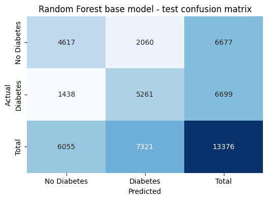

```
- Test Accuracy: 0.7384868421052632
- Test Precision: 0.7186176751809862
- Test Recall: 0.7853410956859233
- Test F1 Score: 0.7504992867332383
```

```python
## 1.3) Random Forest Base Model

# Separate features and target variable
X = diabetes_onehot.drop("diabetes", axis=1)
y = diabetes_onehot["diabetes"]

# Split the dataset into training and testing sets (80:20 split)
X_train, X_test, y_train, y_test = train_test_split(X, y, test_size=0.2, random_state=42)

# Initialize the Random Forest model with default values
rf_clf = RandomForestClassifier(
    random_state=42,
    n_estimators=300,
    max_features='sqrt',
    max_depth= 10,
    min_samples_split=2,
    min_samples_leaf=1
)

# Fit the model on the entire training set
rf_clf.fit(X_train, y_train)

# Test the model performance on the test set
y_test_pred = rf_clf.predict(X_test)

# Compute and print the confusion matrix for the test set
conf_matrix_test = confusion_matrix(y_test, y_test_pred)
print("- Test Confusion Matrix:")
print(conf_matrix_test)

# Function to plot confusion matrix with totals
def plot_confusion_matrix_with_totals(conf_matrix, title):
    cm_with_totals = conf_matrix.copy()
    cm_with_totals = np.vstack([cm_with_totals, np.sum(cm_with_totals, axis=0)])
    cm_with_totals = np.hstack([cm_with_totals, np.sum(cm_with_totals, axis=1).reshape(-1, 1)])

    cm_df = pd.DataFrame(cm_with_totals, index=['No Diabetes', 'Diabetes', 'Total'], columns=['No Diabetes', 'Diabetes', 'Total'])

    plt.figure(figsize=(6, 4))
    sns.heatmap(cm_df, annot=True, fmt='d', cmap='Blues', cbar=False)
    plt.title(title)
    plt.xlabel('Predicted')
    plt.ylabel('Actual')
    plt.show()

# Plot the confusion matrix for the test set
plot_confusion_matrix_with_totals(conf_matrix_test, 'Random Forest base model - test confusion matrix')

# Compute and print additional evaluation metrics for the test set
accuracy_test = accuracy_score(y_test, y_test_pred)
precision_test = precision_score(y_test, y_test_pred)
recall_test = recall_score(y_test, y_test_pred)
f1_test = f1_score(y_test, y_test_pred)

print("- Test Accuracy:", accuracy_test)
print("- Test Precision:", precision_test)
print("- Test Recall:", recall_test)
print("- Test F1 Score:", f1_test)
```

# ------------------------------------------------------------

#### 2) Feature Selection, Cross validation and Testing with one hot encoding

- Feature selection- only selected Features used
- Training, 5-fold cross validation and testing

# ------------------------------------------------------------

#### 2.1) Logistic Regression - Feature Selection and 5-fold Cross Validation

```python
diabetes_lg_importnce =diabetes_clean [['diabetes', 'bmi', 'cholcheck', 'genhlth',  'bp','chol','age', 'heart_disease', 'sex', 'walk', 'stroke', 'phyhlth','activity', 'education', 'income', 'alcohol' ]]
```

```python
diabetes_lg_importnce.head()
```

|  | diabetes | bmi | cholcheck | genhlth | bp | chol | age | heart_disease | sex | walk | stroke | phyhlth | activity | education | income | alcohol |
| --- | --- | --- | --- | --- | --- | --- | --- | --- | --- | --- | --- | --- | --- | --- | --- | --- |
| 0 | 0 | 0.552109 | 1 | 1 | 1 | 0 | 1 | 0 | 1 | 0 | 0 | 2 | 1 | 2 | 2 | 0 |
| 1 | 0 | 0.552109 | 1 | 1 | 1 | 1 | 3 | 0 | 1 | 0 | 1 | 0 | 0 | 2 | 2 | 0 |
| 2 | 0 | 0.552109 | 1 | 0 | 0 | 0 | 3 | 0 | 1 | 0 | 0 | 1 | 1 | 2 | 2 | 0 |
| 3 | 0 | 0.612179 | 1 | 1 | 1 | 1 | 3 | 0 | 1 | 0 | 0 | 0 | 1 | 2 | 2 | 0 |
| 4 | 0 | 0.640678 | 1 | 1 | 0 | 0 | 2 | 0 | 0 | 0 | 0 | 0 | 1 | 2 | 2 | 0 |

```python
cat_lg_importance =['age','income','education','genhlth','phyhlth']
```

```python
# convert only categorical variables/features to dummy/one-hot features
diabetes_lg_importnce_onehot = pd.get_dummies(diabetes_lg_importnce, columns=cat_lg_importance, prefix = cat_lg_importance)

# Replace True/False with 1/0
diabetes_lg_importnce_onehot = diabetes_lg_importnce_onehot.replace({True: 1, False: 0})

#print the dataset
diabetes_lg_importnce_onehot.head()
```

|  | diabetes | bmi | cholcheck | bp | chol | heart_disease | sex | walk | stroke | activity | ... | income_2 | education_0 | education_1 | education_2 | genhlth_0 | genhlth_1 | genhlth_2 | phyhlth_0 | phyhlth_1 | phyhlth_2 |
| --- | --- | --- | --- | --- | --- | --- | --- | --- | --- | --- | --- | --- | --- | --- | --- | --- | --- | --- | --- | --- | --- |
| 0 | 0 | 0.552109 | 1 | 1 | 0 | 0 | 1 | 0 | 0 | 1 | ... | 1 | 0 | 0 | 1 | 0 | 1 | 0 | 0 | 0 | 1 |
| 1 | 0 | 0.552109 | 1 | 1 | 1 | 0 | 1 | 0 | 1 | 0 | ... | 1 | 0 | 0 | 1 | 0 | 1 | 0 | 1 | 0 | 0 |
| 2 | 0 | 0.552109 | 1 | 0 | 0 | 0 | 1 | 0 | 0 | 1 | ... | 1 | 0 | 0 | 1 | 1 | 0 | 0 | 0 | 1 | 0 |
| 3 | 0 | 0.612179 | 1 | 1 | 1 | 0 | 1 | 0 | 0 | 1 | ... | 1 | 0 | 0 | 1 | 0 | 1 | 0 | 1 | 0 | 0 |
| 4 | 0 | 0.640678 | 1 | 0 | 0 | 0 | 0 | 0 | 0 | 1 | ... | 1 | 0 | 0 | 1 | 0 | 1 | 0 | 1 | 0 | 0 |

5 rows × 27 columns

```
- Cross-validation scores: [0.73364486 0.73327103 0.73233645 0.73551402 0.73588785]
- Mean cross-validation score: 0.7341308411214954
- Training Confusion Matrix:
[[18864  7932]
 [ 6292 20412]]
- Training Accuracy: 0.7341308411214953
- Training Precision: 0.7201524132091448
- Training Recall: 0.7643798681845416
- Training F1 Score: 0.7416073245167853
- Test Confusion Matrix: LR with feature selection & CV
[[4759 1918]
 [1565 5134]]
```

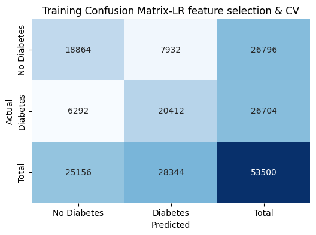

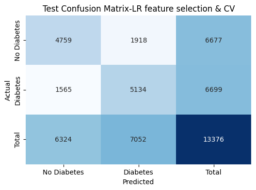

```
- Test Accuracy: 0.7396082535885168
- Test Precision: 0.7280204197390812
- Test Recall: 0.7663830422451112
- Test F1 Score: 0.7467093302305287
```

```python
## 2.1) Logistic Regression - Feature Selection and 5-fold Cross Validation

# Separate features and target variable
X = diabetes_lg_importnce_onehot.drop("diabetes", axis=1)
y = diabetes_lg_importnce_onehot["diabetes"]

# Split the dataset into training and testing sets (80:20 split)
X_train, X_test, y_train, y_test = train_test_split(X, y, test_size=0.2, random_state=42)

# Initialize the Logistic Regression model with increased iterations
logreg = LogisticRegression(
    random_state=42,
    max_iter=1000,  # Increase max_iter as needed
    C=1.0,          # Regularization strength
    penalty='l1',   # Regularization penalty
    solver='saga'   # Solver
)

# Perform 5-fold cross-validation on the training set
cv_scores = cross_val_score(logreg, X_train, y_train, cv=5, scoring='accuracy')

# Print the cross-validation scores and mean score
print("- Cross-validation scores:", cv_scores)
print("- Mean cross-validation score:", cv_scores.mean())

# Perform cross-validation predictions on the training set
y_train_pred = cross_val_predict(logreg, X_train, y_train, cv=5)

# Compute and print the confusion matrix for the training set
conf_matrix_train = confusion_matrix(y_train, y_train_pred)
print("- Training Confusion Matrix:")
print(conf_matrix_train)

# Compute and print additional evaluation metrics for the training set
accuracy_train = accuracy_score(y_train, y_train_pred)
precision_train = precision_score(y_train, y_train_pred)
recall_train = recall_score(y_train, y_train_pred)
f1_train = f1_score(y_train, y_train_pred)

print("- Training Accuracy:", accuracy_train)
print("- Training Precision:", precision_train)
print("- Training Recall:", recall_train)
print("- Training F1 Score:", f1_train)

# Fit the model on the entire training set
logreg.fit(X_train, y_train)

# Test the model performance on the test set
y_test_pred = logreg.predict(X_test)

# Compute and print the confusion matrix for the test set
conf_matrix_test = confusion_matrix(y_test, y_test_pred)
print("- Test Confusion Matrix: LR with feature selection & CV")
print(conf_matrix_test)

# Function to plot confusion matrix with totals
def plot_confusion_matrix_with_totals(conf_matrix, title):
    cm_with_totals = conf_matrix.copy()
    cm_with_totals = np.vstack([cm_with_totals, np.sum(cm_with_totals, axis=0)])
    cm_with_totals = np.hstack([cm_with_totals, np.sum(cm_with_totals, axis=1).reshape(-1, 1)])

    cm_df = pd.DataFrame(cm_with_totals, index=['No Diabetes', 'Diabetes', 'Total'], columns=['No Diabetes', 'Diabetes', 'Total'])

    plt.figure(figsize=(6,4))
    sns.heatmap(cm_df, annot=True, fmt='d', cmap='Blues', cbar=False)
    plt.title(title)
    plt.xlabel('Predicted')
    plt.ylabel('Actual')
    plt.show()

# Plot the confusion matrix for the training set
plot_confusion_matrix_with_totals(conf_matrix_train, 'Training Confusion Matrix-LR feature selection & CV')

# Plot the confusion matrix for the test set
plot_confusion_matrix_with_totals(conf_matrix_test, 'Test Confusion Matrix-LR feature selection & CV')

# Compute and print additional evaluation metrics for the test set
accuracy_test = accuracy_score(y_test, y_test_pred)
precision_test = precision_score(y_test, y_test_pred)
recall_test = recall_score(y_test, y_test_pred)
f1_test = f1_score(y_test, y_test_pred)

print("- Test Accuracy:", accuracy_test)
print("- Test Precision:", precision_test)
print("- Test Recall:", recall_test)
print("- Test F1 Score:", f1_test)
```

#### 2.2) DT - Feature Selection, Cross Validation with One-Hot encoded categories

```python
# The following features were selected using feaature importance, gini impurity, in DT
diabetes_dt_importance = diabetes_clean[['diabetes', 'bp','chol','bmi','smoker','heart_disease','age','income',  'education', 'genhlth', 'phyhlth', 'fruits',  'menthlth', 'sex', 'walk', 'veggies', 'activity' , 'nodocbccost']]
```

```python
diabetes_dt_importance.head()
```

|  | diabetes | bp | chol | bmi | smoker | heart_disease | age | income | education | genhlth | phyhlth | fruits | menthlth | sex | walk | veggies | activity | nodocbccost |
| --- | --- | --- | --- | --- | --- | --- | --- | --- | --- | --- | --- | --- | --- | --- | --- | --- | --- | --- |
| 0 | 0 | 1 | 0 | 0.552109 | 0 | 0 | 1 | 2 | 2 | 1 | 2 | 0 | 1 | 1 | 0 | 1 | 1 | 0 |
| 1 | 0 | 1 | 1 | 0.552109 | 1 | 0 | 3 | 2 | 2 | 1 | 0 | 1 | 0 | 1 | 0 | 0 | 0 | 0 |
| 2 | 0 | 0 | 0 | 0.552109 | 0 | 0 | 3 | 2 | 2 | 0 | 1 | 1 | 0 | 1 | 0 | 1 | 1 | 0 |
| 3 | 0 | 1 | 1 | 0.612179 | 1 | 0 | 3 | 2 | 2 | 1 | 0 | 1 | 0 | 1 | 0 | 1 | 1 | 0 |
| 4 | 0 | 0 | 0 | 0.640678 | 1 | 0 | 2 | 2 | 2 | 1 | 0 | 1 | 0 | 0 | 0 | 1 | 1 | 0 |

```python
cat_dt_importance = ['genhlth', 'phyhlth', 'menthlth','age', 'education', 'income']
```

```python
# convert only categorical variables/features to dummy/one-hot features
diabetes_dt_importance_onehot = pd.get_dummies(diabetes_dt_importance, columns=cat_dt_importance, prefix = cat_dt_importance)

# Replace True/False with 1/0
diabetes_dt_importance_onehot = diabetes_dt_importance_onehot.replace({True: 1, False: 0})

#print the dataset
diabetes_dt_importance_onehot.head()
```

|  | diabetes | bp | chol | bmi | smoker | heart_disease | fruits | sex | walk | veggies | ... | education_2 | genhlth_0 | genhlth_1 | genhlth_2 | phyhlth_0 | phyhlth_1 | phyhlth_2 | menthlth_0 | menthlth_1 | menthlth_2 |
| --- | --- | --- | --- | --- | --- | --- | --- | --- | --- | --- | --- | --- | --- | --- | --- | --- | --- | --- | --- | --- | --- |
| 0 | 0 | 1 | 0 | 0.552109 | 0 | 0 | 0 | 1 | 0 | 1 | ... | 1 | 0 | 1 | 0 | 0 | 0 | 1 | 0 | 1 | 0 |
| 1 | 0 | 1 | 1 | 0.552109 | 1 | 0 | 1 | 1 | 0 | 0 | ... | 1 | 0 | 1 | 0 | 1 | 0 | 0 | 1 | 0 | 0 |
| 2 | 0 | 0 | 0 | 0.552109 | 0 | 0 | 1 | 1 | 0 | 1 | ... | 1 | 1 | 0 | 0 | 0 | 1 | 0 | 1 | 0 | 0 |
| 3 | 0 | 1 | 1 | 0.612179 | 1 | 0 | 1 | 1 | 0 | 1 | ... | 1 | 0 | 1 | 0 | 1 | 0 | 0 | 1 | 0 | 0 |
| 4 | 0 | 0 | 0 | 0.640678 | 1 | 0 | 1 | 0 | 0 | 1 | ... | 1 | 0 | 1 | 0 | 1 | 0 | 0 | 1 | 0 | 0 |

5 rows × 31 columns

```
- Cross-validation scores: [0.6346729  0.64336449 0.63728972 0.63616822 0.63897196]
- Mean cross-validation score: 0.6380934579439252
- Training Confusion Matrix:
[[18040  8756]
 [10606 16098]]
- Training Accuracy: 0.6380934579439252
- Training Precision: 0.6477025830852177
- Training Recall: 0.6028310365488316
- Training F1 Score: 0.6244617712091237
- Test Confusion Matrix:
[[4504 2173]
 [2625 4074]]
```

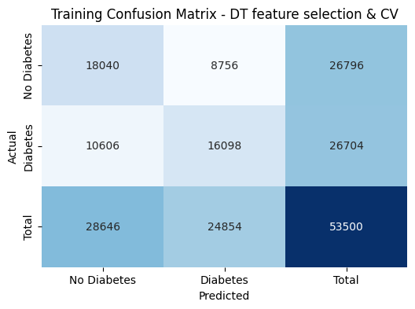

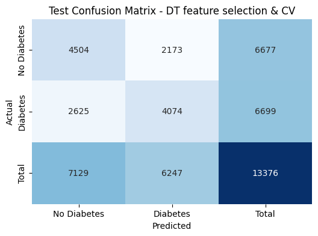

```
- Test Accuracy: 0.6412978468899522
- Test Precision: 0.6521530334560589
- Test Recall: 0.6081504702194357
- Test F1 Score: 0.629383593387919
```

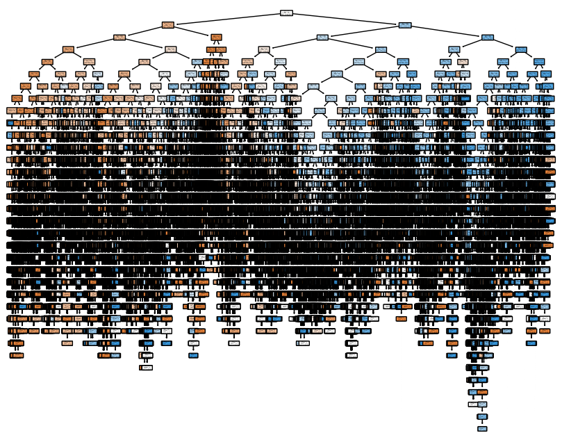

```python
## 2.2) DT - Feature Selection, Cross Validation with One-Hot encoded categories

# Separate features and target variable
X = diabetes_dt_importance_onehot.drop("diabetes", axis=1)
y = diabetes_dt_importance_onehot["diabetes"]

# Split the dataset into training and testing sets (80:20 split)
X_train, X_test, y_train, y_test = train_test_split(X, y, test_size=0.2, random_state=42)

# Initialize the Decision Tree model with default values
tree_clf = DecisionTreeClassifier(
    random_state=42,
    max_depth=None,  # Default value: None (nodes are expanded until all leaves are pure or until all leaves contain less than min_samples_split samples)
    min_samples_split=2,  # Default value: 2 (the minimum number of samples required to split an internal node)
    min_samples_leaf=1  # Default value: 1 (the minimum number of samples required to be at a leaf node)
)

# Perform 5-fold cross-validation on the training set
cv_scores = cross_val_score(tree_clf, X_train, y_train, cv=5, scoring='accuracy')

# Print the cross-validation scores and mean score
print("- Cross-validation scores:", cv_scores)
print("- Mean cross-validation score:", cv_scores.mean())

# Perform cross-validation predictions on the training set
y_train_pred = cross_val_predict(tree_clf, X_train, y_train, cv=5)

# Compute and print the confusion matrix for the training set
conf_matrix_train = confusion_matrix(y_train, y_train_pred)
print("- Training Confusion Matrix:")
print(conf_matrix_train)

# Compute and print additional evaluation metrics for the training set
accuracy_train = accuracy_score(y_train, y_train_pred)
precision_train = precision_score(y_train, y_train_pred)
recall_train = recall_score(y_train, y_train_pred)
f1_train = f1_score(y_train, y_train_pred)

print("- Training Accuracy:", accuracy_train)
print("- Training Precision:", precision_train)
print("- Training Recall:", recall_train)
print("- Training F1 Score:", f1_train)

# Fit the model on the entire training set
tree_clf.fit(X_train, y_train)

# Test the model performance on the test set
y_test_pred = tree_clf.predict(X_test)

# Compute and print the confusion matrix for the test set
conf_matrix_test = confusion_matrix(y_test, y_test_pred)
print("- Test Confusion Matrix:")
print(conf_matrix_test)

# Function to plot confusion matrix with totals
def plot_confusion_matrix_with_totals(conf_matrix, title):
    cm_with_totals = conf_matrix.copy()
    cm_with_totals = np.vstack([cm_with_totals, np.sum(cm_with_totals, axis=0)])
    cm_with_totals = np.hstack([cm_with_totals, np.sum(cm_with_totals, axis=1).reshape(-1, 1)])

    cm_df = pd.DataFrame(cm_with_totals, index=['No Diabetes', 'Diabetes', 'Total'], columns=['No Diabetes', 'Diabetes', 'Total'])

    plt.figure(figsize=(6,4))
    sns.heatmap(cm_df, annot=True, fmt='d', cmap='Blues', cbar=False)
    plt.title(title)
    plt.xlabel('Predicted')
    plt.ylabel('Actual')
    plt.show()

# Plot the confusion matrix for the training set
plot_confusion_matrix_with_totals(conf_matrix_train, 'Training Confusion Matrix - DT feature selection & CV')

# Plot the confusion matrix for the test set
plot_confusion_matrix_with_totals(conf_matrix_test, 'Test Confusion Matrix - DT feature selection & CV')

# Compute and print additional evaluation metrics for the test set
accuracy_test = accuracy_score(y_test, y_test_pred)
precision_test = precision_score(y_test, y_test_pred)
recall_test = recall_score(y_test, y_test_pred)
f1_test = f1_score(y_test, y_test_pred)

print("- Test Accuracy:", accuracy_test)
print("- Test Precision:", precision_test)
print("- Test Recall:", recall_test)
print("- Test F1 Score:", f1_test)

# Visualize the decision tree
plt.figure(figsize=(10,8))
plot_tree(tree_clf, filled=True, feature_names=X.columns, class_names=["No Diabetes", "Diabetes"], rounded=True)
plt.show()
```

#### 2.3) Random Forest - Feature Selection, Cross Validation with One-Hot encoded categories

```python
# The following features were selected using feaature importance, gini impurity, in DT
diabetes_rf_importance = diabetes_clean[['diabetes', 'bp','chol','bmi','smoker','heart_disease','age','income',  'education', 'genhlth', 'phyhlth', 'fruits',  'menthlth', 'sex', 'walk', 'veggies', 'activity' , 'nodocbccost']]
```

```python
cat_rf_importance = ['genhlth', 'phyhlth', 'menthlth','age', 'education', 'income']
```

```python
# convert only categorical variables/features to dummy/one-hot features
diabetes_rf_importance_onehot = pd.get_dummies(diabetes_rf_importance, columns=cat_rf_importance, prefix = cat_rf_importance)

# Replace True/False with 1/0
diabetes_rf_importance_onehot = diabetes_rf_importance_onehot.replace({True: 1, False: 0})

#print the dataset
diabetes_rf_importance_onehot.head()
```

|  | diabetes | bp | chol | bmi | smoker | heart_disease | fruits | sex | walk | veggies | ... | age_0 | age_1 | age_2 | age_3 | education_0 | education_1 | education_2 | income_0 | income_1 | income_2 |
| --- | --- | --- | --- | --- | --- | --- | --- | --- | --- | --- | --- | --- | --- | --- | --- | --- | --- | --- | --- | --- | --- |
| 0 | 0 | 1 | 0 | 0.552109 | 0 | 0 | 0 | 1 | 0 | 1 | ... | 0 | 1 | 0 | 0 | 0 | 0 | 1 | 0 | 0 | 1 |
| 1 | 0 | 1 | 1 | 0.552109 | 1 | 0 | 1 | 1 | 0 | 0 | ... | 0 | 0 | 0 | 1 | 0 | 0 | 1 | 0 | 0 | 1 |
| 2 | 0 | 0 | 0 | 0.552109 | 0 | 0 | 1 | 1 | 0 | 1 | ... | 0 | 0 | 0 | 1 | 0 | 0 | 1 | 0 | 0 | 1 |
| 3 | 0 | 1 | 1 | 0.612179 | 1 | 0 | 1 | 1 | 0 | 1 | ... | 0 | 0 | 0 | 1 | 0 | 0 | 1 | 0 | 0 | 1 |
| 4 | 0 | 0 | 0 | 0.640678 | 1 | 0 | 1 | 0 | 0 | 1 | ... | 0 | 0 | 1 | 0 | 0 | 0 | 1 | 0 | 0 | 1 |

5 rows × 31 columns

```
- Cross-validation scores: [0.68803738 0.69186916 0.68981308 0.68981308 0.69476636]
- Mean cross-validation score: 0.6908598130841123
- Training Confusion Matrix:
[[17835  8961]
 [ 7578 19126]]
- Training Accuracy: 0.6908598130841122
- Training Precision: 0.6809556022359099
- Training Recall: 0.7162222887956861
- Training F1 Score: 0.6981438557427315
- Test Confusion Matrix:
[[4482 2195]
 [1874 4825]]
```

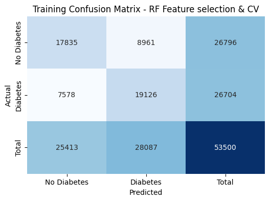

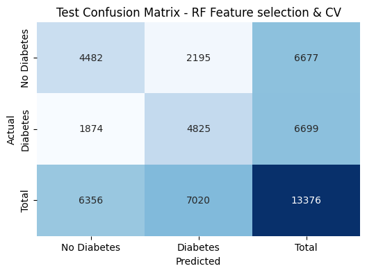

```
- Test Accuracy: 0.6957984449760766
- Test Precision: 0.6873219373219374
- Test Recall: 0.7202567547395133
- Test F1 Score: 0.7034040381952037
```

```python
# 2.3) Random Forest - Feature Selection, Cross Validation with One-Hot encoded categories

# Separate features and target variable
X = diabetes_rf_importance_onehot.drop("diabetes", axis=1)
y = diabetes_rf_importance_onehot["diabetes"]

# Split the dataset into training and testing sets (80:20 split)
X_train, X_test, y_train, y_test = train_test_split(X, y, test_size=0.2, random_state=42)

# Initialize the Random Forest model
rf_model = RandomForestClassifier(random_state=42, n_estimators=100)

# Perform 5-fold cross-validation on the training set
cv_scores = cross_val_score(rf_model, X_train, y_train, cv=5, scoring='accuracy')

# Print the cross-validation scores and mean score
print("- Cross-validation scores:", cv_scores)
print("- Mean cross-validation score:", cv_scores.mean())

# Perform cross-validation predictions on the training set
y_train_pred = cross_val_predict(rf_model, X_train, y_train, cv=5)

# Compute and print the confusion matrix for the training set
conf_matrix_train = confusion_matrix(y_train, y_train_pred)
print("- Training Confusion Matrix:")
print(conf_matrix_train)

# Compute and print additional evaluation metrics for the training set
accuracy_train = accuracy_score(y_train, y_train_pred)
precision_train = precision_score(y_train, y_train_pred)
recall_train = recall_score(y_train, y_train_pred)
f1_train = f1_score(y_train, y_train_pred)

print("- Training Accuracy:", accuracy_train)
print("- Training Precision:", precision_train)
print("- Training Recall:", recall_train)
print("- Training F1 Score:", f1_train)

# Fit the model on the entire training set
rf_model.fit(X_train, y_train)

# Test the model performance on the test set
y_test_pred = rf_model.predict(X_test)

# Compute and print the confusion matrix for the test set
conf_matrix_test = confusion_matrix(y_test, y_test_pred)
print("- Test Confusion Matrix:")
print(conf_matrix_test)

# Function to plot confusion matrix with totals
def plot_confusion_matrix_with_totals(conf_matrix, title):
    cm_with_totals = conf_matrix.copy()
    cm_with_totals = np.vstack([cm_with_totals, np.sum(cm_with_totals, axis=0)])
    cm_with_totals = np.hstack([cm_with_totals, np.sum(cm_with_totals, axis=1).reshape(-1, 1)])

    cm_df = pd.DataFrame(cm_with_totals, index=['No Diabetes', 'Diabetes', 'Total'], columns=['No Diabetes', 'Diabetes', 'Total'])

    plt.figure(figsize=(6, 4))
    sns.heatmap(cm_df, annot=True, fmt='d', cmap='Blues', cbar=False)
    plt.title(title)
    plt.xlabel('Predicted')
    plt.ylabel('Actual')
    plt.show()

# Plot the confusion matrix for the training set
plot_confusion_matrix_with_totals(conf_matrix_train, 'Training Confusion Matrix - RF feature selection & CV')

# Plot the confusion matrix for the test set
plot_confusion_matrix_with_totals(conf_matrix_test, 'Test Confusion Matrix - RF feature selection & CV')

# Compute and print additional evaluation metrics for the test set
accuracy_test = accuracy_score(y_test, y_test_pred)
precision_test = precision_score(y_test, y_test_pred)
recall_test = recall_score(y_test, y_test_pred)
f1_test = f1_score(y_test, y_test_pred)

print("- Test Accuracy:", accuracy_test)
print("- Test Precision:", precision_test)
print("- Test Recall:", recall_test)
print("- Test F1 Score:", f1_test)
```

# ------------------------------------------------------------

#### 4) Hyperparameter Optimization using GreadsearchCV

# ------------------------------------------------------------

#### 3.1) LR - Hyperparameter Optimization using GreadsearchCV

**Hyperparameter Optimization in Logistic regression**

To determine the optimal values for three most important parameters, Regularization strength, penalty, and solver for the Logistic Regression model, a technique called Grid Search with Cross-Validation (GridSearchCV) was used. This method exhaustively searches through a specified parameter grid to find the best combination of parameter values based on cross-validation performance. using GridSearchCV, we can systematically evaluate the performance of the Logistic Regression model with different combinations of Regularization strength (C), penalty, and solver values to determine the optimal accuracy of the model.

The typical ranges of three most important parameters in logistic regression areas follows:

- Regularization strength -prevent overfitting by adding a penalty for larger coefficients in the model. Regularization Strength (C in Logistic Regression) controls the inverse of regularization strength. A smaller C value indicates stronger regularization,
  - values [0.01, 0.1, 1, 10, 100]
- Regularization penalty- specifies the type of regularization to be applied. Common options are 'l1' (Lasso) for promoting sparsity, 'l2' (Ridge) for promoting smaller coefficients, and 'elasticnet' which is a combination of both.

ptions: ['l1', 'l2', 'elasticnet', 'none']

- solver: The algorithm used for optimization in logistic regression
  - Options: ['newton-cg', 'lbfgs', 'liblinear', 'sag', 'saga']

Note: Smaller values Regularization strength specify stronger regularization, not all solvers support all penalties and solvers in this context refers to algorithm to use in the optimization problem

```
Best parameters found: {'C': 1, 'max_iter': 1000, 'penalty': 'l2', 'solver': 'newton-cg'}
Best cross-validation score: 0.7342429906542056
- Training Confusion Matrix:
[[18864  7932]
 [ 6286 20418]]
- Training Accuracy: 0.7342429906542056
- Training Precision: 0.7202116402116402
- Training Recall: 0.7646045536249251
- Training F1 Score: 0.7417444690667344
- Test Confusion Matrix:
[[4758 1919]
 [1564 5135]]
- Test Accuracy: 0.7396082535885168
- Test Precision: 0.7279557697760136
- Test Recall: 0.7665323182564562
- Test F1 Score: 0.7467461644732059
```

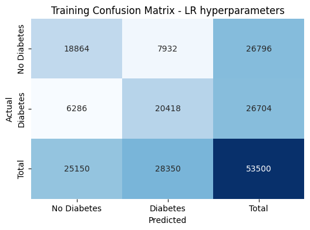

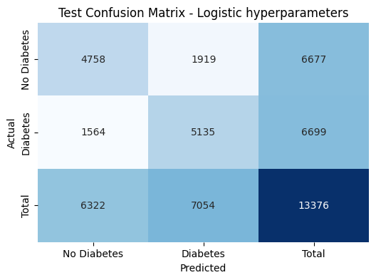

```python
## 3.1) LR - Hyperparameter Optimization using GreadsearchCV

# Separate features and target variable
X = diabetes_lg_importnce_onehot.drop("diabetes", axis=1)
y = diabetes_lg_importnce_onehot["diabetes"]

# Split the dataset into training and testing sets (80:20 split)
X_train, X_test, y_train, y_test = train_test_split(X, y, test_size=0.2, random_state=42)

# Define the parameter grid with valid combinations
param_grid = [
    {'C': [0.01, 0.1, 1, 10, 100], 'penalty': ['l2', 'none'], 'solver': ['newton-cg', 'lbfgs', 'sag', 'saga'], 'max_iter': [1000]},
    {'C': [0.01, 0.1, 1, 10, 100], 'penalty': ['l1', 'l2'], 'solver': ['liblinear'], 'max_iter': [1000]},
    {'C': [0.01, 0.1, 1, 10, 100], 'penalty': ['elasticnet'], 'solver': ['saga'], 'max_iter': [1000], 'l1_ratio': [0.5]}
]

# Initialize the Logistic Regression model
logreg = LogisticRegression(random_state=42)

# Initialize GridSearchCV with 5-fold cross-validation
grid_search = GridSearchCV(logreg, param_grid, cv=5, scoring='accuracy', n_jobs=-1, error_score=np.nan)

# Fit GridSearchCV on the training data
grid_search.fit(X_train, y_train)

# Print the best parameters and the corresponding score
print("Best parameters found:", grid_search.best_params_)
print("Best cross-validation score:", grid_search.best_score_)

# Use the best model to perform cross-validation predictions on the training set
best_model = grid_search.best_estimator_
y_train_pred = cross_val_predict(best_model, X_train, y_train, cv=5)

# Compute and print the confusion matrix for the training set
conf_matrix_train = confusion_matrix(y_train, y_train_pred)
print("- Training Confusion Matrix:")
print(conf_matrix_train)

# Compute and print additional evaluation metrics for the training set
accuracy_train = accuracy_score(y_train, y_train_pred)
precision_train = precision_score(y_train, y_train_pred)
recall_train = recall_score(y_train, y_train_pred)
f1_train = f1_score(y_train, y_train_pred)

print("- Training Accuracy:", accuracy_train)
print("- Training Precision:", precision_train)
print("- Training Recall:", recall_train)
print("- Training F1 Score:", f1_train)

# Use the best model to predict on the test set
y_test_pred = best_model.predict(X_test)

# Compute and print the confusion matrix for the test set
conf_matrix_test = confusion_matrix(y_test, y_test_pred)
print("- Test Confusion Matrix:")
print(conf_matrix_test)

# Compute and print additional evaluation metrics for the test set
accuracy_test = accuracy_score(y_test, y_test_pred)
precision_test = precision_score(y_test, y_test_pred)
recall_test = recall_score(y_test, y_test_pred)
f1_test = f1_score(y_test, y_test_pred)

print("- Test Accuracy:", accuracy_test)
print("- Test Precision:", precision_test)
print("- Test Recall:", recall_test)
print("- Test F1 Score:", f1_test)

# Function to plot confusion matrix
def plot_confusion_matrix_with_totals(conf_matrix, title):
    cm_with_totals = conf_matrix.copy()
    cm_with_totals = np.vstack([cm_with_totals, np.sum(cm_with_totals, axis=0)])
    cm_with_totals = np.hstack([cm_with_totals, np.sum(cm_with_totals, axis=1).reshape(-1, 1)])

    cm_df = pd.DataFrame(cm_with_totals, index=['No Diabetes', 'Diabetes', 'Total'], columns=['No Diabetes', 'Diabetes', 'Total'])

    plt.figure(figsize=(6, 4))
    sns.heatmap(cm_df, annot=True, fmt='d', cmap='Blues', cbar=False)
    plt.title(title)
    plt.xlabel('Predicted')
    plt.ylabel('Actual')
    plt.show()

# Plot the confusion matrix for the training set
plot_confusion_matrix_with_totals(conf_matrix_train, 'Training Confusion Matrix - LR hyperparameters')

# Plot the confusion matrix for the test set
plot_confusion_matrix_with_totals(conf_matrix_test, 'Test Confusion Matrix - LR hyperparameters')
```

#### 3.2) DT - Hyperparameter Optimization using GreadsearchCV

To find the optimal combination of three most relevant hyperparameters for a Decision Tree classifier, max_depth, min_samples_split, and min_samples_leaf, GridSearchCV was used in a similar manner to the Logistic Regression. using GridSearchCV, we can systematically evaluate the performance of the DecisionTreeClassifier with different combinations of parameters values to determine the optimal settings for your specific dataset. For a Decision Tree, the typical ranges for these hyperparameters aregiven as follows:

- max_depth: Controls the maximum depth of the tree.
  - values: [None, 10, 20, 30, 40, 50]
- min_samples_split: The minimum number of samples required to split an internal node.
  - Values: [2, 5, 10, 20]
- min_samples_leaf: The minimum number of samples required to be at a leaf node.
  - values: [1, 2, 5, 10]

```
Best parameters found: {'max_depth': 10, 'min_samples_leaf': 5, 'min_samples_split': 20}
Best cross-validation score: 0.7181495327102804
- Training Confusion Matrix:
[[18846  7950]
 [ 5794 20910]]
- Training Accuracy: 0.7431028037383177
- Training Precision: 0.7245322245322245
- Training Recall: 0.7830287597363691
- Training F1 Score: 0.752645597869124
- Test Confusion Matrix:
[[4605 2072]
 [1599 5100]]
```

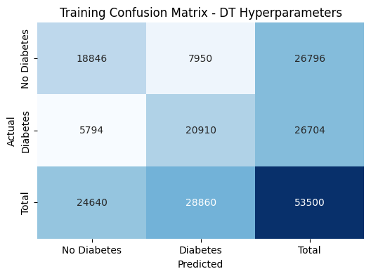

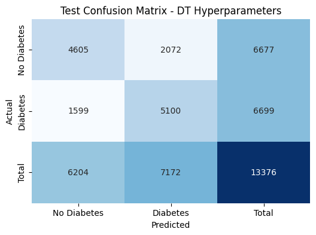

```
- Test Accuracy: 0.7255532296650717
- Test Precision: 0.7110987172336866
- Test Recall: 0.761307657859382
- Test F1 Score: 0.7353471270997044
```

```python
##  Decision Tree - Hyperparameter Optimization using GreadsearchCV

# Separate features and target variable
X = diabetes_dt_importance_onehot.drop("diabetes", axis=1)
y = diabetes_dt_importance_onehot["diabetes"]

# Split the dataset into training and testing sets (80:20 split)
X_train, X_test, y_train, y_test = train_test_split(X, y, test_size=0.2, random_state=42)



# Define the parameter grid
param_grid = {
    'max_depth': [None, 10, 20, 30, 40, 50],
    'min_samples_split': [2, 5, 10, 20],
    'min_samples_leaf': [1, 2, 5, 10]
}

# Initialize the Decision Tree model
tree_clf = DecisionTreeClassifier(random_state=42)

# Initialize GridSearchCV with 5-fold cross-validation
grid_search = GridSearchCV(tree_clf, param_grid, cv=5, scoring='accuracy', n_jobs=-1)

# Fit GridSearchCV on the training data
grid_search.fit(X_train, y_train)

# Print the best parameters and the corresponding score
print("Best parameters found:", grid_search.best_params_)
print("Best cross-validation score:", grid_search.best_score_)

# Use the best model to perform cross-validation predictions on the training set
best_model = grid_search.best_estimator_
y_train_pred = best_model.predict(X_train)

# Compute and print the confusion matrix for the training set
conf_matrix_train = confusion_matrix(y_train, y_train_pred)
print("- Training Confusion Matrix:")
print(conf_matrix_train)

# Compute and print additional evaluation metrics for the training set
accuracy_train = accuracy_score(y_train, y_train_pred)
precision_train = precision_score(y_train, y_train_pred)
recall_train = recall_score(y_train, y_train_pred)
f1_train = f1_score(y_train, y_train_pred)

print("- Training Accuracy:", accuracy_train)
print("- Training Precision:", precision_train)
print("- Training Recall:", recall_train)
print("- Training F1 Score:", f1_train)

# Use the best model to predict on the test set
y_test_pred = best_model.predict(X_test)

# Compute and print the confusion matrix for the test set
conf_matrix_test = confusion_matrix(y_test, y_test_pred)
print("- Test Confusion Matrix:")
print(conf_matrix_test)

# Function to plot confusion matrix with totals
def plot_confusion_matrix_with_totals(conf_matrix, title):
    cm_with_totals = conf_matrix.copy()
    cm_with_totals = np.vstack([cm_with_totals, np.sum(cm_with_totals, axis=0)])
    cm_with_totals = np.hstack([cm_with_totals, np.sum(cm_with_totals, axis=1).reshape(-1, 1)])

    cm_df = pd.DataFrame(cm_with_totals, index=['No Diabetes', 'Diabetes', 'Total'], columns=['No Diabetes', 'Diabetes', 'Total'])

    plt.figure(figsize=(6, 4))
    sns.heatmap(cm_df, annot=True, fmt='d', cmap='Blues', cbar=False)
    plt.title(title)
    plt.xlabel('Predicted')
    plt.ylabel('Actual')
    plt.show()

# Plot the confusion matrix for the training set
plot_confusion_matrix_with_totals(conf_matrix_train, 'Training Confusion Matrix - DT Hyperparameters')

# Plot the confusion matrix for the test set
plot_confusion_matrix_with_totals(conf_matrix_test, 'Test Confusion Matrix - DT Hyperparameters')

# Compute and print additional evaluation metrics for the test set
accuracy_test = accuracy_score(y_test, y_test_pred)
precision_test = precision_score(y_test, y_test_pred)
recall_test = recall_score(y_test, y_test_pred)
f1_test = f1_score(y_test, y_test_pred)

print("- Test Accuracy:", accuracy_test)
print("- Test Precision:", precision_test)
print("- Test Recall:", recall_test)
print("- Test F1 Score:", f1_test)
```

```python
## DT - Hyperparameter Optimization using GreadsearchCV

# Separate features and target variable
diabetes_dt_importance_onehot
X = diabetes_dt_importance_onehot.drop("diabetes", axis=1)
y = diabetes_dt_importance_onehot["diabetes"]

# Split the dataset into training and testing sets (80:20 split)
X_train, X_test, y_train, y_test = train_test_split(X, y, test_size=0.2, random_state=42)

# Define the parameter grid
param_grid = {
    'max_depth': [None, 10, 20, 30, 40, 50],
    'min_samples_split': [2, 5, 10, 20],
    'min_samples_leaf': [1, 2, 5, 10]
}

# Initialize the Decision Tree model
tree_clf = DecisionTreeClassifier(random_state=42)

# Initialize GridSearchCV with 5-fold cross-validation
grid_search = GridSearchCV(tree_clf, param_grid, cv=5, scoring='accuracy', n_jobs=-1)

# Fit GridSearchCV on the training data
grid_search.fit(X_train, y_train)

# Print the best parameters and the corresponding score
print("Best parameters found:", grid_search.best_params_)
print("Best cross-validation score:", grid_search.best_score_)

# Use the best model to predict on the test set
best_model = grid_search.best_estimator_
y_test_pred = best_model.predict(X_test)

# Compute and print the confusion matrix for the test set
conf_matrix_test = confusion_matrix(y_test, y_test_pred)
print("- Test Confusion Matrix:")
print(conf_matrix_test)

# Compute and print additional evaluation metrics for the test set
accuracy_test = accuracy_score(y_test, y_test_pred)
precision_test = precision_score(y_test, y_test_pred)
recall_test = recall_score(y_test, y_test_pred)
f1_test = f1_score(y_test, y_test_pred)

print("- Test Accuracy:", accuracy_test)
print("- Test Precision:", precision_test)
print("- Test Recall:", recall_test)
print("- Test F1 Score:", f1_test)
```

```
Best parameters found: {'max_depth': 10, 'min_samples_leaf': 1, 'min_samples_split': 20}
Best cross-validation score: 0.7181495327102804
- Test Confusion Matrix:
[[4608 2069]
 [1614 5085]]
- Test Accuracy: 0.7246561004784688
- Test Precision: 0.710791165781381
- Test Recall: 0.7590685176892074
- Test F1 Score: 0.7341370100339276
```

#### 3.3) RF - Hyperparameter Optimization using GreadsearchCV

##### Random Forest Hyper parameters

To optimize the values of three most relevant hyperparameters of the Random Forest model to maximize accuracy, GridSearchCV is used in a similar manner as the LR and DT models above.For Random Forests, the typical ranges for these hyperparameters are:

- n_estimators: Number of trees in the forest.
  - values: [50, 100, 200, 300]
- max_features: The number of features to consider when looking for the best split.
  - values: ['sqrt', 'log2', None]
- max_depth: The maximum depth of the tree.
  - values: [None, 10, 20, 30, 40, 50]

```
Best parameters found: {'max_depth': 10, 'max_features': 'sqrt', 'n_estimators': 300}
Best cross-validation score: 0.7316635514018692
- Training Confusion Matrix:
[[18225  8571]
 [ 5785 20919]]
- Training Accuracy: 0.7316635514018691
- Training Precision: 0.7093591047812818
- Training Recall: 0.7833657878969443
- Training F1 Score: 0.7445278855393814
- Test Confusion Matrix:
[[4572 2105]
 [1417 5282]]
```

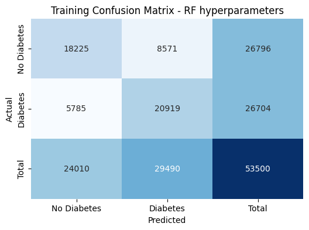

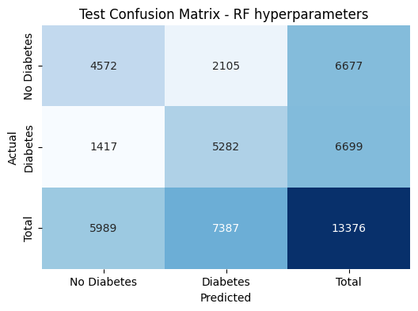

```
- Test Accuracy: 0.7366925837320574
- Test Precision: 0.7150399350209828
- Test Recall: 0.7884758919241678
- Test F1 Score: 0.7499645037626012
```

```python
## 3.3) RF - Hyperparameter Optimization using GreadsearchCV

# Separate features and target variable
X = diabetes_rf_importance_onehot.drop("diabetes", axis=1)
y = diabetes_rf_importance_onehot["diabetes"]

# Split the dataset into training and testing sets (80:20 split)
X_train, X_test, y_train, y_test = train_test_split(X, y, test_size=0.2, random_state=42)

# Define the parameter grid
param_grid = {
    'n_estimators': [50, 100, 200, 300],
    'max_features': ['sqrt', 'log2', None],
    'max_depth': [None, 10, 20, 30, 40, 50]
}

# Initialize the Random Forest model
rf_clf = RandomForestClassifier(random_state=42)

# Initialize GridSearchCV with 5-fold cross-validation
grid_search = GridSearchCV(rf_clf, param_grid, cv=5, scoring='accuracy', n_jobs=-1)

# Fit GridSearchCV on the training data
grid_search.fit(X_train, y_train)

# Print the best parameters and the corresponding score
print("Best parameters found:", grid_search.best_params_)
print("Best cross-validation score:", grid_search.best_score_)

# Use the best model to perform cross-validation predictions on the training set
best_model = grid_search.best_estimator_
y_train_pred = cross_val_predict(best_model, X_train, y_train, cv=5)

# Compute and print the confusion matrix for the training set
conf_matrix_train = confusion_matrix(y_train, y_train_pred)
print("- Training Confusion Matrix:")
print(conf_matrix_train)

# Compute and print additional evaluation metrics for the training set
accuracy_train = accuracy_score(y_train, y_train_pred)
precision_train = precision_score(y_train, y_train_pred)
recall_train = recall_score(y_train, y_train_pred)
f1_train = f1_score(y_train, y_train_pred)

print("- Training Accuracy:", accuracy_train)
print("- Training Precision:", precision_train)
print("- Training Recall:", recall_train)
print("- Training F1 Score:", f1_train)

# Use the best model to predict on the test set
y_test_pred = best_model.predict(X_test)

# Compute and print the confusion matrix for the test set
conf_matrix_test = confusion_matrix(y_test, y_test_pred)
print("- Test Confusion Matrix:")
print(conf_matrix_test)

# Function to plot confusion matrix with totals
def plot_confusion_matrix_with_totals(conf_matrix, title):
    cm_with_totals = conf_matrix.copy()
    cm_with_totals = np.vstack([cm_with_totals, np.sum(cm_with_totals, axis=0)])
    cm_with_totals = np.hstack([cm_with_totals, np.sum(cm_with_totals, axis=1).reshape(-1, 1)])

    cm_df = pd.DataFrame(cm_with_totals, index=['No Diabetes', 'Diabetes', 'Total'], columns=['No Diabetes', 'Diabetes', 'Total'])

    plt.figure(figsize=(6, 4))
    sns.heatmap(cm_df, annot=True, fmt='d', cmap='Blues', cbar=False)
    plt.title(title)
    plt.xlabel('Predicted')
    plt.ylabel('Actual')
    plt.show()

# Plot the confusion matrix for the training set
plot_confusion_matrix_with_totals(conf_matrix_train, 'Training Confusion Matrix - RF hyperparameters')

# Plot the confusion matrix for the test set
plot_confusion_matrix_with_totals(conf_matrix_test, 'Test Confusion Matrix - RF hyperparameters ')

# Compute and print additional evaluation metrics for the test set
accuracy_test = accuracy_score(y_test, y_test_pred)
precision_test = precision_score(y_test, y_test_pred)
recall_test = recall_score(y_test, y_test_pred)
f1_test = f1_score(y_test, y_test_pred)

print("- Test Accuracy:", accuracy_test)
print("- Test Precision:", precision_test)
print("- Test Recall:", recall_test)
print("- Test F1 Score:", f1_test)
```

-------------------------------- END -----------------------------------

------------------------------- Y. Mengistu, July 2nd, 2024 ------------